# Customer Data Analysis

We want to analyze our customer data, and better understand them. Please identify:

```r
load('exerciseData.rda')
```

- The top 10 email_cols by active enterprise users

```r
library(dplyr)
# many to many
combine_email_and_tenant_data <- function(relation, emails, tenants, email_col_num, tenant_col_num){
    # save the column names for later
    old_email_name <- colnames(emails)[email_col_num]
    old_tenant_name <- colnames(tenants)[tenant_col_num]

    # rename the columns for ease of reference
    colnames(emails)[email_col_num] <- "email_col"
    colnames(tenants)[tenant_col_num] <- "tenant_col"

    # create a joined table of tenants and emails
    email_tenant <- left_join(relation, tenants, by='tenant_id') %>%
        left_join(., emails, by='email_id') %>%
        select(tenant_id, email_col, tenant_col) #%>%

    # remove non-zero tenant_col, sort by tenant_col and then tenant id, and remove NULL rows
    email_tenant <- email_tenant[email_tenant$tenant_col > 0,]
    email_tenant <- arrange(email_tenant,desc(tenant_col), tenant_id)
    email_tenant <- email_tenant[complete.cases(email_tenant), ]

    # get a count of unique tenants and create an empty matrix to hold the deduped data
    unique_tenants <- unique(email_tenant$tenant_id)
    result <- matrix(NA, nrow=length(unique_tenants), ncol=2, dimnames=list(NULL, c("email_col", "tenant_col")))

    # create temporary vectors to loop through, as well as placeholder looping variables
    tenant_ids <- data.matrix(email_tenant$tenant_id, rownames.force = NA)
    email_cols <- data.matrix(email_tenant$email_col, rownames.force = NA)
    tenant_cols <- data.matrix(email_tenant$tenant_col, rownames.force = NA)
    temp_email_cols <- email_cols[1]
    temp_tenant_col <- tenant_cols[1]
    index <- 1

    # for a given tenant, make a list of all associated email_cols, find the mode,
    # and attribute those tenant_cols to that email_col.  I chose to use this method of
    # deduping because there is no way to do a proportional attribution for a list of values.
    # Instead of trying to assign fractional portions of value from the tenant_col, it was
    # less misleading to simply assing them all to the most common email_col value for that tenant
    for (i in 2:length(tenant_ids)){
        if (tenant_ids[i] != tenant_ids[i-1]){
            # get the most frequent email_col from temp list AKA temp_email_cols.mode()
            # TODO: create tiebreaker method
            most_freq_email_col <- names(sort(summary(as.factor(temp_email_cols)), decreasing=T)[1])
            # add it to the matrix
            result[index, 1] <- most_freq_email_col
            # add tenant_col to the matrix
            result[index, 2] <- temp_tenant_col
            # advance index
            index <- index + 1
            # set list of email_cols for next tenant and set temp tenant_col
            temp_email_cols <- email_cols[i]
            temp_tenant_col <- tenant_cols[i]
        } else {
            # add email_col to list of email_cols for a given tenant
            temp_email_cols <- append(temp_email_cols, email_cols[i])
        }
    }
    # remove null rows
    result <- result[complete.cases(result), ]
    result <- as.data.frame(result)

    # convert to numeric values and group by email_col, then sort by tenant_col
    result$tenant_col <- as.numeric(as.character(result$tenant_col))
    result <- group_by(result, email_col) %>%
        summarise(tenant_col = sum(tenant_col)) %>%
        arrange(desc(tenant_col))

    colnames(result)[1] <- old_email_name
    colnames(result)[2] <- old_tenant_name
    return(result)
}
# dataset_emails$country = 3
# dataset_tenants$active_enterprise_users_last_30d = 6
country_activeusers <- combine_email_and_tenant_data(dataset_relation, dataset_emails, dataset_tenants, 3, 6)
head(country_activeusers, n = 10)
```

| country | active_enterprise_users_last_30d |
| --- | --- |
| United States | 76662 |
| Canada | 10702 |
| Sweden | 2127 |
|  | 1708 |
| United Kingdom | 1208 |
| Australia | 648 |
| Netherlands | 331 |
| Israel | 278 |
| Germany | 232 |
| New Zealand | 216 |

- The top 10 operating systems by open and total tickets

```r
#many to many
# use function from previous exercise
# dataset_emails$sperating_system = 8
# dataset_tenants$account_open_tickets = 12
operatingsystem_opentickets <- combine_email_and_tenant_data(dataset_relation, dataset_emails, dataset_tenants, 8, 12)
head(operatingsystem_opentickets, n = 10)
```

| sperating_system | account_open_tickets |
| --- | --- |
| Mac OS X | 447 |
| Windows 10 | 136 |
| Windows 8.1 | 93 |
| Windows 7 | 38 |
| Linux | 33 |
| Ubuntu | 5 |
| Android | 3 |
| iOS | 3 |
| Other | 2 |
| Windows 8 | 2 |

```r
# dataset_emails$sperating_system = 8
# dataset_tenants$account_total_tickets = 13
operatingsystem_totaltickets <- combine_email_and_tenant_data(dataset_relation, dataset_emails, dataset_tenants, 8, 13)
head(operatingsystem_totaltickets, n = 10)
```

| sperating_system | account_total_tickets |
| --- | --- |
| Mac OS X | 5561 |
| Windows 10 | 2240 |
| Windows 8.1 | 1721 |
| Windows 7 | 1217 |
| Linux | 580 |
| iOS | 147 |
| Ubuntu | 18 |
| Other | 11 |
| Android | 10 |
| Windows 8 | 9 |

- The distribution of pageviews per group

```r
library(dplyr)
#one to many
pageviews_by_metric <- function(pageviews, emails, email_col_num){
    # save the column names for later
    old_email_name <- colnames(emails)[email_col_num]

    # rename the columns for ease of reference
    colnames(emails)[email_col_num] <- "email_col"

    # join tables, select and group columns and sum the number of pageviews
    group_pageview <- left_join(pageviews, emails, by='email_id') %>%
        select(email_id, visits, email_col) %>%
        group_by(email_col) %>%
        summarise(total_pageviews = sum(visits))

    # order descending by pageviews
    group_pageview <- arrange(group_pageview, -total_pageviews)

    # rename column back to old name
    colnames(group_pageview)[1] <- old_email_name

    return(group_pageview)
}
# dataset_emails$source_group = 7
output <- pageviews_by_metric(dataset_pageviews, dataset_emails, 7)
output
```

| source_group | total_pageviews |
| --- | --- |
| Google | 2777772 |
| Direct | 1224493 |
| Other | 221866 |
| Github | 132623 |
| Auth0 Child | 100718 |
| Metrics Bug | 82323 |
| Duck Duck Go | 49622 |
| Twitter | 26903 |
| Scotch | 22774 |
| Dzone | 19560 |

[output cut: 37 more lines]

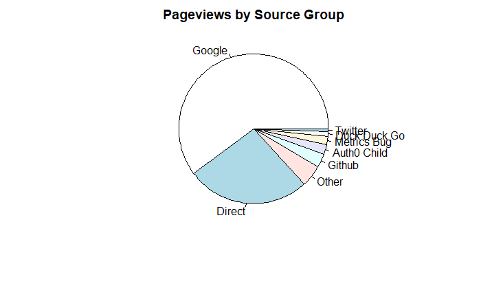

```r
top_results <- head(output, n = 8)
pie(top_results$total_pageviews, top_results$source_group, main="Pageviews by Source Group")
```

- The distribution differences on pageviews per login method

```r
library(dplyr)
#one to many
# use function from previous exercise
# dataset_emails$login_method = 11
output <- pageviews_by_metric(dataset_pageviews, dataset_emails, 11)
output
```

| login_method | total_pageviews |
| --- | --- |
| auth0 | 2341139 |
| google-oauth2 | 1683006 |
| github | 595127 |
| windowslive | 127431 |
| google-apps | 30018 |
| linkedin | 20612 |
| hus_aETmN8sUX5uzHjRZ | 3271 |
| adfs | 1576 |
| hus_hUfFpFnqNDMDJeog | 619 |
| hus_iJckQ078KuHB36p1 | 551 |

[output cut: 10 more lines]

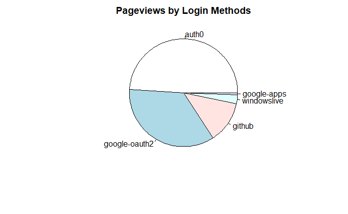

```r
top_results <- head(output, n = 5)
pie(top_results$total_pageviews, top_results$login_method, main="Pageviews by Login Methods")
```

- What differences do you find between developers and non-developers?
  - There are far more developers than non – over 11 times as many
  - Company sizes are faily similarly distributed between devs and non-devs in terms of mean and standard deviation
  - Most other metrics are also similarly distributed (e.g., country, source_group, browser). However the operating systems for devopers put Mac OS X in a slight lead with Windows 10 right behind and Windows 7 trailing. However, for non-developers, Windows 10 has a dominant lead by almost 40% over Mac OS X, with Windows 7 in a close third place.
  - Even though developer roles outnumber non-devs 11:1, they account for over 16 times as many pageviews as non-devs
  - Developers account for over 36 times as many active users in the last 30 days as non-devs

```r
library(dplyr)
# select only rows that are developers or non
devs <- dataset_emails[dataset_emails$role == "developer",]
non_devs <- dataset_emails[dataset_emails$role == "non-developer",]
# calcualte total number of devs/non-devs
print(c("num (devs):", nrow(devs)))
```

```
[1] "num (devs):" "8230"
```

```r
print(c("num (non-devs):", nrow(non_devs)))
```

```
[1] "num (non-devs):" "721"
```

```r
# calculate mean and sttdev of company size for each role type
dev_employees <- devs[complete.cases(devs$company_employees), ]$company_employees
non_dev_employees <- non_devs[complete.cases(non_devs$company_employees), ]$company_employees
print(c("mean company size (dev):", mean(dev_employees)))
```

```
[1] "mean company size (dev):" "3571.51742712294"
```

```r
print(c("mean company size (non-devs):", mean(non_dev_employees)))
```

```
[1] "mean company size (non-devs):" "3930.60185185185"
```

```r
print(c("stddev company size (dev):", sd(dev_employees)))
```

```
[1] "stddev company size (dev):" "27781.0792851743"
```

```r
print(c("stddev company size (non-devs):", sd(non_dev_employees)))
```

```
[1] "stddev company size (non-devs):" "27750.7748562022"
```

```r
# compare operating systems
arrange(as.data.frame(table(devs$sperating_system)), desc(Freq))
```

| Var1 | Freq |
| --- | --- |
| Mac OS X | 2957 |
| Windows 10 | 2824 |
| Windows 7 | 934 |
| Linux | 704 |
| Windows 8.1 | 324 |
| Ubuntu | 228 |
| Android | 131 |
| iOS | 67 |
| Windows 8 | 24 |
| Chrome OS | 12 |

[output cut: 7 more lines]

```r
arrange(as.data.frame(table(non_devs$sperating_system)), desc(Freq))
```

| Var1 | Freq |
| --- | --- |
| Windows 10 | 260 |
| Mac OS X | 188 |
| Windows 7 | 127 |
| Android | 53 |
| iOS | 36 |
| Windows 8.1 | 33 |
| Linux | 15 |
| Ubuntu | 4 |
| Windows 8 | 4 |
| Windows Phone | 1 |

```r
# compare pageviews
head(pageviews_by_metric(dataset_pageviews, dataset_emails, 4), n = 4)
```

| role | total_pageviews |
| --- | --- |
| developer | 3163661 |
|  | 978833 |
| non-developer | 187224 |
| Software Developer | 184870 |

```r
# compare active users in the last 30 days
combine_email_and_tenant_data(dataset_relation, dataset_emails, dataset_tenants, 4, 4)
```

| role | active_users_last_30d |
| --- | --- |
| engineering | 1675959 |
|  | 823494 |
| developer | 122512 |
| operations | 6273 |
| non-developer | 3360 |
| sales | 1671 |
| Software Developer | 1311 |
| product | 702 |
| ceo | 271 |
| marketing | 202 |

[output cut: 17 more lines]

- What are the most and least used technologies in tenants?

```r
library(stringr)
expand_commas <- function(dataset_, col_num){
    # save the column names for later
    old_email_name <- colnames(dataset_)[col_num]
    # rename the column for ease of reference
    colnames(dataset_)[col_num] <- "metric"
    # make column into vector and remove empty strings
    metric <- as.vector(dataset_$metric)
    metric <- metric[metric != ""]

    # get count of commas in elements and make a matrix to store the output
    comma_count <- sum(str_count(metric, ", "))
    metric_reduced <- matrix(NA , nrow=length(metric) + comma_count, ncol=1, dimnames=list(NULL, c("metric")))

    # for each value, if it has a comma, split it into a list and add each one to the matrix
    # if it doesn't have a comma, add it to the list
    index <- 1
    for (t in 1:length(metric)){
        if (grepl(", ", metric[t])){
            strings <- strsplit(metric[t], ", ")
            strings <- strings[[1]]
            for (s in 1:length(strings)){
                metric_reduced[index, 1] <- strings[s]
                index <- index + 1
            }
        } else {
            metric_reduced[index, 1] <- metric[t]
            index = index + 1
        }
    }

    # convert to a data frame and get a frequency count
    metric_reduced <- as.data.frame(metric_reduced)
    frequencies <- as.data.frame(lapply(metric_reduced, table))

    return(frequencies)
}
# dataset_tenants$technologies_used = 9
result <- expand_commas(dataset_tenants, 9)
# display the bottom 5 and top 5
head(result[order(result$metric.Freq),], n = 5)
```

|  | metric.Var1 | metric.Freq |
| --- | --- | --- |
| 10 | node_auth0 | 5 |
| 4 | dotnet | 10 |
| 11 | omniauth | 14 |
| 15 | ruby | 30 |
| 14 | react_native | 51 |

```r
head(result[order(-result$metric.Freq),], n = 5)
```

|  | metric.Var1 | metric.Freq |
| --- | --- | --- |
| 8 | lock | 4094 |
| 3 | auth0_js | 791 |
| 6 | java | 176 |
| 2 | apple | 156 |
| 16 | wordpress | 156 |

- Please mark any inconsistencies you find in the data that you’d research further if you were working at Auth0
  - The column dataset_emails$sperating_system has a typo
  - The column dataset_tenants$technologies_used should be broken out into a seperate dataset. Comma separated lists in data sets can get nasty. The dataset would have two columns: “tenant_id” and “technology_used”, where the latter column would be a single technology. If there are multiple techs used for one tenant, then there would be multiple rows.
  - There is a similar problem for dataset_tenants$connection_types
  - There seem to be inconsistensies in columns with strings whether the default value is the empty string or NULL. I would change these to default to NULL for ease of data analysis.
  - The column datatset_emails$login_method seems to have quite a few values that all start with hus_ followed by an aplha-numeric suffix. Most of the values for these are fairly non-informative (None, Other, blank, NA). These email_ids could be test data from auth0 itself. However, I would want to follow up and make sure that these aren’t users that are trying to hide their tracks for nefarious purposes.
- Create at least 3 visualizations using R which you consider interesting for the provided data
  - The first chart simply shows the distribution of connection types. Most users are using username/pw or other social media accounts to log in, as opposed to using more secure methods.
  - The second chart shows that there are two correlation types between active users and active enterprise users. One correlation seems to follow a linear curve where both types increase with the other. The other correlation shows no relationship between increasing active users and active enterprise users.
  - The final chart is just for fun to see how many people are not using their native browser for the Mac and Windows operating systems

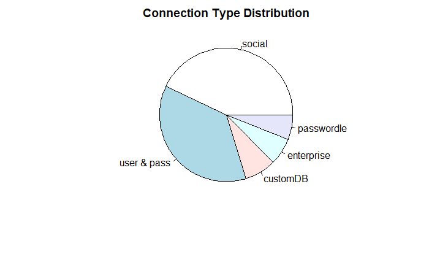

```r
library(ggplot2)
library(plotly)
# dataset_tenants$connection_types = 8
result <- expand_commas(dataset_tenants, 8)
result <- result[order(-result$metric.Freq),]
pie(result$metric.Freq, result$metric.Var1, main="Connection Type Distribution")
```

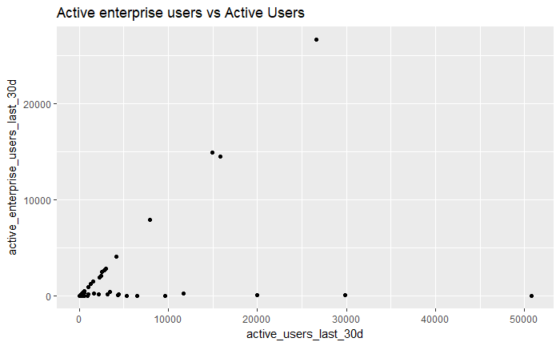

```r
tmp <- filter(dataset_tenants, active_users_last_30d < 1500000 & active_users_last_30d > 0 & active_enterprise_users_last_30d > 10)
ggplot(data=tmp, aes(x=active_users_last_30d, y=active_enterprise_users_last_30d, group=1)) +
    geom_point() +
    ggtitle("Active enterprise users vs Active Users")
```

```r
windows_traitors <- filter(dataset_emails, grepl("Windows.*", sperating_system) & !grepl("IE", browser))
mac_traitors <- filter(dataset_emails, grepl("Mac OS X", sperating_system) & !grepl("Safari", browser))
plot_ly(
  x = c("windows_traitors", "mac_traitors"),
  y = c(nrow(windows_traitors), nrow(mac_traitors)),
  name = "Number of Traitors (to their Operating Systems)",
  type = "bar"
)
```

[interactive chart not shown]